# Simulation of Diffusion-Reaction Model (GLV Reaction Term)

Longxiao, LMU python version: 3.10.19

In this notebook, we are going to simulate the dynamics of diffusion reaction model with the GLV reaction term. The full model is $$ \frac{\partial N_i}{\partial t} = D_{i}\frac{\partial^2 N_i}{\partial x^2} + f(N_j) $$ where $f(N_j)$ is GLV function.

```python
import numpy as np
import matplotlib.pyplot as plt
from scipy.integrate import solve_ivp
import scipy.sparse as sp
import scipy.sparse.linalg as spla
import pickle
from joblib import Parallel, delayed
from tqdm.notebook import tqdm
from scipy.optimize import curve_fit
```

## Explicit Finite Difference Method

We first apply the forward Euler method for time discretization. The spatial domain is discretized with grid spacing $\Delta x$, and time is discretized with step size $\Delta t$. Denote $N_i(x = k\Delta x,\, t = \ell \Delta t)$ by $u_{k,\ell}^i$. The diffusion term is approximated by the standard second-order central difference, $$ \frac{\partial^2 N_i(k \Delta x,t)}{\partial x^2} \approx \frac{u_{k+1,\ell}^i - 2 u_{k,\ell}^i + u_{k-1,\ell}^i}{(\Delta x)^2}. $$ The temporal derivative is approximated by a forward difference, $$ \frac{\partial N_i(k \Delta x, \ell \Delta t)}{\partial t} \approx \frac{u_{k,\ell+1}^i - u_{k,\ell}^i}{\Delta t}. $$ Combining these approximations yields the explicit update scheme $$ u_{k,\ell+1}^i = u_{k,\ell}^i + \Delta t \left[ D_i \frac{u_{k+1,\ell}^i - 2 u_{k,\ell}^i + u_{k-1,\ell}^i}{(\Delta x)^2} + f_i(\mathbf{u}_{k,\ell}) \right], $$ where $\mathbf{u}_{k,\ell} = (u_{k,\ell}^1, \dots, u_{k,\ell}^S)$ is the vector of species abundances at grid point $k$ and time step $\ell$. This explicit scheme is computationally efficient and is therefore used for coarse simulations and parameter scans, although it is subject to stability constraints on $\Delta t$.

```python
class ReactionDiffusion1D:
    """
    parameters
    ----
    D : ndarray, shape (n,)
        dispersal coefficient of each species
    r : ndarray, shape (n,)
        intrinsic rate of each species
    A : ndarray, shape (n, n)
        interaction matrix
    xspan : tuple
        space (xmin, xmax)
    nx : int
        number of spatial grids
    dt : float
        time steps
    """

    def __init__(self, D, r, A, xspan=(0, 1), nx=200, dt=1e-4):
        self.D = np.array(D)
        self.r = np.array(r)
        self.A = np.array(A)
        self.n = len(D)

        self.xmin, self.xmax = xspan
        self.nx = nx
        self.dt = dt

        self.x = np.linspace(self.xmin, self.xmax, nx)
        self.dx = self.x[1] - self.x[0]

        self.N = np.zeros((self.n, self.nx))

    def laplacian_1d(self, u):
        # second ordered central difference
        # Neumann boundary

        dx = self.dx
        lap = np.zeros_like(u)

        lap[1:-1] = (u[2:] - 2*u[1:-1] + u[:-2]) / dx**2

        lap[0] = (u[1] - u[0]) * 2 / dx**2
        lap[-1] = (u[-2] - u[-1]) * 2 / dx**2

        return lap

    def set_initial(self, N0):
        # initial state, in the shape of (n, nx)
        self.N = np.array(N0).copy()

    def reaction_term(self, N):
        # GLV reaction
        interaction = self.A @ N
        return N * self.r[:, None] * (1 - interaction)

    def diffusion_term(self, N):
        # random diffusion
        diff = np.zeros_like(N)
        for i in range(self.n):
            diff[i] = self.D[i] * self.laplacian_1d(N[i])
        return diff

    def step(self):
        # time steps
        R = self.reaction_term(self.N)
        D = self.diffusion_term(self.N)
        self.N += self.dt * (R + D)
        self.N = np.maximum(self.N, 0.0)

    def run(self, steps, record_interval=None):
        # run steps, return records (if given)
        if record_interval is None:
            for _ in range(steps):
                self.step()
            return None

        records = []
        for k in range(steps):
            self.step()
            if k % record_interval == 0:
                records.append(self.N.copy())
        return records
```

Example: Fisher-KPP initial state is species occupied space $x< - 0.9$

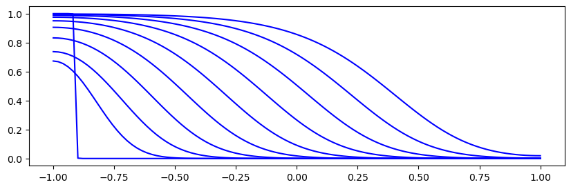

```python
n = 1

D = [0.01]
r = [1]
A = np.array([[1]])

model = ReactionDiffusion1D(D, r, A, xspan=(-1, 1), nx=100, dt=1e-4)

x = model.x
N0 = np.zeros((n, len(x)))
N0[0] = 1
N0[0][x>=-0.9] = 0

model.set_initial(N0)

records = model.run(steps=100000, record_interval=10000)

fig, ax = plt.subplots(figsize=(10, 3))

for i in range(0,10):
    plt.plot(x, records[i][0], color = 'b')

plt.show()
```

Example: two symmetric species.

```python
n = 2

D = [0.1, 0.1]
r = [1, 1]
A = np.array([[1, 1.5],
              [1.5, 1]])

model = ReactionDiffusion1D(D, r, A, xspan=(-1, 1), nx=500, dt=1e-6)

x = model.x
N0 = np.zeros((n, len(x)))
N0[0] = 1
N0[0][x>=0] = 0
N0[1] = 1
N0[1][x<=0] = 0

model.set_initial(N0)

records = model.run(steps=100000, record_interval=10)
```

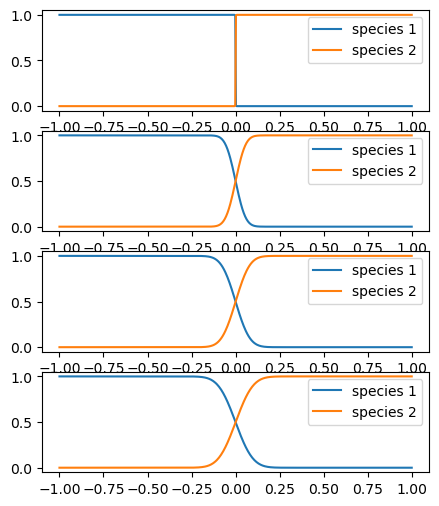

```python
fig, axes = plt.subplots(4, 1, figsize=(5, 6))
axes = axes.flatten()

for i in range(0,4):
    ax = axes[i]
    record = records[1000*i]
    ax.plot(x, record[0], label='species 1')
    ax.plot(x, record[1], label='species 2')
    ax.legend()

plt.show()
```

Now we want to explore about the dynamics with different parameters, where two species are not symmetric. Generally, we would assume that if one species dispersal faster or reproduce faster, it might outperform the other one, thus finally take over. Also, we would guess there might be a balance between dispersal and growth, where two species get balanced. To show this, we scan parameters and simulate the system for 100000 steps, and measure the position of coexist center, where $N_1(x^*) = N_2(x^*)$.

```python
# single simulation:
# for a given parameter coefficient, multiplied to the parameters in the symmetric model
def run_single(a, b):

    D = [0.1 * a, 0.1]
    r = [1 * b, 1]

    A = np.array([
        [1, 1.5],
        [1.5, 1]
    ])

    model = ReactionDiffusion1D(
        D,
        r,
        A,
        xspan=(-1, 1),
        nx=1000,
        dt=1e-6
    )

    x = model.x

    N0 = np.zeros((n, len(x)))

    #initial state
    N0[0] = 1
    N0[0][x > 0] = 0
    N0[1] = 1
    N0[1][x < 0] = 0

    model.set_initial(N0)

    records = model.run(
        steps=100000,
        record_interval=100
    )

    final_state = records[-1]

    return (a, b, final_state)
```

```python
n = 2

#a_list = np.logspace(-1, 1.5, 100)
#b_list = np.logspace(-1, 0.5, 60)
#a_list = np.logspace(-1, 1, 10)
#b_list = np.logspace(-1, 1, 10)

#scan parameter coefficient
da = 0.05
db = 0.05
a_list = np.arange(0, 2 , da)
b_list = np.arange(0, 2 , db)

params = [
    (a, b)
    for a in a_list
    for b in b_list
]

# -------------------------
# run in parallel
# n_jobs=-1: all cpu core
# -------------------------
outputs = Parallel(
    n_jobs=-1,
    backend="loky"
)(
    delayed(run_single)(a, b)
    for a, b in tqdm(params)
)

results = {
    (a, b): final_state
    for a, b, final_state in outputs
}
```

Now, for each parameter combination $(a,b)$ in system $$ \partial_t N_1 = D \nabla^2 N_1 + r N_1(1 - N_1 - 1.5 N_2)\\ \partial_t N_2 = \nabla^2 N_2 + N_2(1 - N_2 - 1.5 N_1) $$ where $D = a$, $r = b$, we have the result distribution after several runs. For the results, we want to find the position of the center.

```python
def get_equal_front(x, u1, u2):

    diff = u1 - u2

    # change of the sign
    sign_change = np.where(diff[:-1] * diff[1:] <= 0)[0]

    if len(sign_change) > 0:

        i = sign_change[0]

        x1, x2 = x[i], x[i+1]
        y1, y2 = diff[i], diff[i+1]

        xf = x1 - y1 * (x2 - x1) / (y2 - y1)

        return -xf

    # if no equal points,
    # one species nearly take over
    left = diff[0]
    right = diff[-1]

    if left > 0 and right > 0:
        return -1     # species1 everywhere

    if left < 0 and right < 0:
        return 1      # species2 everywhere

    return np.nan
```

Then we combine this position information with parameters, that is, mapping the $xf$ to $(a,b)$.

```python
def build_front_map(a_list, b_list, results, x=None):

    if x is None:
        x = np.linspace(-1, 1, 1000)

    front_map = np.zeros((len(a_list), len(b_list)))

    for i, a in enumerate(a_list):
        for j, b in enumerate(b_list):

            final_state = results[(a, b)]

            u1 = final_state[0]
            u2 = final_state[1]

            front_map[i, j] = get_equal_front(x, u1, u2)

    return front_map
```

Draw the result: heat map.

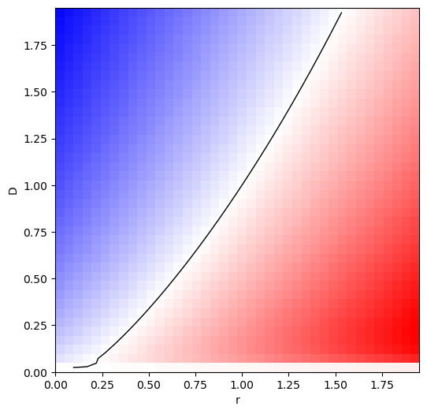

```python
front_map_Dr = build_front_map(a_list, b_list, results, x=None)
plt.figure(figsize=(6,6))

# maxima to make sure that color in the map is balanced
max_abs = np.nanmax(np.abs(front_map_Dr))

# using continuous diverging colormap
im = plt.imshow(front_map_Dr,
                origin='lower',
                extent=[b_list[0], b_list[-1],
                        a_list[0], a_list[-1]],
                aspect=(b_list[-1]-b_list[0])/(a_list[-1]-a_list[0]),
                cmap='bwr',  # blue-white-red
                vmin=-max_abs,
                vmax=+max_abs)

plt.xlabel("r")
plt.ylabel("D")
#plt.title("Phase diagram (N1 = N2 front)")

# legend color bar
#cbar = plt.colorbar(im, label="Front position / dominance")
#cbar.set_ticks([-max_abs, 0, max_abs])
#cbar.set_ticklabels(['Species1', 'Equal', 'Species2'])

# null-cline shows the condition of balance
# where the center do not move
plt.contour(front_map_Dr, levels=[0], colors='k', linewidths=1,
            origin='lower',
            extent=[b_list[0], b_list[-1],
                    a_list[0], a_list[-1]])

plt.show()
```

```python
with open("resultsDr.pkl", "wb") as f:
    pickle.dump(results, f)

print("saved")
```

```
saved
```

Similarly, we scan dispersal and competition rate, as in $$ \partial_t N_1 = D \nabla^2 N_1 + N_1(1 - N_1 - a_{1,2} N_2)\\ \partial_t N_2 = \nabla^2 N_2 + N_2(1 - N_2 - 1.5 N_1) $$ where $D = a$, $a_{1,2} = b$.

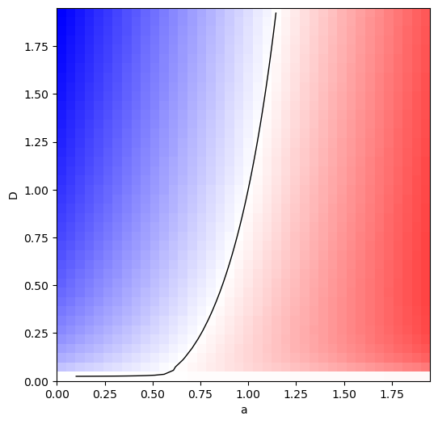

```python
with open("resultsDa_005.pkl", "rb") as f:
    results = pickle.load(f)

da = 0.05
db = 0.05
a_list = np.arange(0, 2 , da)
b_list = np.arange(0, 2 , db)

front_map_Da = build_front_map(a_list, b_list, results, x=None)
plt.figure(figsize=(6,6))

# maxima to make sure that color in the map is balanced
max_abs = np.nanmax(np.abs(front_map_Da))

# using continuous diverging colormap
im = plt.imshow(front_map_Da,
                origin='lower',
                extent=[b_list[0], b_list[-1],
                        a_list[0], a_list[-1]],
                aspect=(b_list[-1]-b_list[0])/(a_list[-1]-a_list[0]),
                cmap='bwr',  # blue-white-red
                vmin=-max_abs,
                vmax=+max_abs)

plt.xlabel("a")
plt.ylabel("D")
#plt.title("Phase diagram (N1 = N2 front)")

# legend color bar
#cbar = plt.colorbar(im, label="Front position / dominance")
#cbar.set_ticks([-max_abs, 0, max_abs])
#cbar.set_ticklabels(['Species1', 'Equal', 'Species2'])

# null-cline shows the condition of balance
# where the center do not move
plt.contour(front_map_Da, levels=[0], colors='k', linewidths=1,
            origin='lower',
            extent=[b_list[0], b_list[-1],
                    a_list[0], a_list[-1]])

plt.show()
```

And logarithm scale

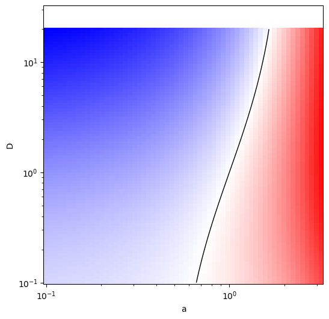

```python
with open("resultsDa_log.pkl", "rb") as f:
    results = pickle.load(f)

a_list = np.logspace(-1, 1.5, 100)
b_list = np.logspace(-1, 0.5, 60)

front_map_Da_log = build_front_map(a_list, b_list, results, x=None)

plt.figure(figsize=(6,6))

max_abs = np.nanmax(np.abs(front_map_Da_log))

B, A = np.meshgrid(b_list, a_list)

im = plt.pcolormesh(
    B,
    A,
    front_map_Da_log,
    shading='auto',
    cmap='bwr',
    vmin=-max_abs,
    vmax=+max_abs
)

plt.xscale('log')
plt.yscale('log')

plt.xlabel("a")
plt.ylabel("D")

#plt.title("Phase diagram (N1 = N2 front)")

# colorbar
#cbar = plt.colorbar(im, label="Front position / dominance")
#cbar.set_ticks([-max_abs, 0, max_abs])
#cbar.set_ticklabels(['Species1', 'Equal', 'Species2'])

plt.contour(
    B,
    A,
    front_map_Da_log,
    levels=[0],
    colors='k',
    linewidths=1
)

plt.show()
```

## IMEX semi-implicit Method

The explicit method may become unstable when diffusion is strong or when the system exhibits stiff dynamics. To improve numerical stability and accuracy, we employ an implicit--explicit (IMEX) scheme, in which the diffusion term is treated implicitly while the reaction term is treated explicitly. The discretized equation takes the form $$ \frac{u_{k,\ell+1}^i - u_{k,\ell}^i}{\Delta t} = D_i \nabla^2 u_{k,\ell+1}^i + f_i(\mathbf{u}_{k,\ell}). $$

```python
class ReactionDiffusionIMEX:
    """
    PDE
    ---
    \partial_t N_i = D_i \partial_xx N_i
             + r_i N_i (1 - Σ_j A_ij N_j)
    """

    def __init__(
        self,
        D,
        r,
        A,
        xspan=(-1.0, 1.0),
        nx=256,
        dt=1e-3,
    ):

        self.D = np.array(D, dtype=float)
        self.r = np.array(r, dtype=float)
        self.A = np.array(A, dtype=float)

        self.nspecies = len(D)

        self.xmin, self.xmax = xspan
        self.nx = nx
        self.dt = dt

        self.x = np.linspace(self.xmin, self.xmax, nx)
        self.dx = self.x[1] - self.x[0]

        self.N = np.zeros((self.nspecies, self.nx))

        self.last_linf_error = 0.0
        self.last_l2_error = 0.0

        # Laplacian
        self.L = self._build_laplacian_matrix()

        # implicit solver
        self.solvers = []
        I = sp.identity(self.nx, format='csr')

        for Di in self.D:
            Aimp = I - self.dt * Di * self.L
            solver = spla.factorized(Aimp.tocsc())
            self.solvers.append(solver)

    # =========================================================
    # Laplacian
    # =========================================================

    def _build_laplacian_matrix(self):

        nx = self.nx
        dx = self.dx

        L = sp.lil_matrix((nx, nx))

        # inner grids
        for i in range(2, nx - 2):
            L[i, i - 2] = -1
            L[i, i - 1] = 16
            L[i, i] = -30
            L[i, i + 1] = 16
            L[i, i + 2] = -1

        # boundary grid
        L[1, 0] = 1
        L[1, 1] = -2
        L[1, 2] = 1

        L[nx - 2, nx - 3] = 1
        L[nx - 2, nx - 2] = -2
        L[nx - 2, nx - 1] = 1

        # Neumann boundary condition
        L[0, 0] = -2
        L[0, 1] = 2

        L[nx - 1, nx - 2] = 2
        L[nx - 1, nx - 1] = -2

        # scaling
        L /= (12 * dx**2)

        # boundary correction
        L[0, :] *= 12
        L[1, :] *= 12
        L[nx - 2, :] *= 12
        L[nx - 1, :] *= 12

        return L.tocsr()

    # =========================================================

    def set_initial(self, N0):
        self.N = np.array(N0, dtype=float).copy()

    # =========================================================

    def reaction_term(self, N):
        interaction = self.A @ N
        return N * self.r[:, None] * (1.0 - interaction)

    def step(self):

        Nold = self.N.copy()

        # reaction (explicit)
        R = self.reaction_term(self.N)
        rhs = self.N + self.dt * R

        Nnew = np.zeros_like(self.N)

        for i in range(self.nspecies):
            Nnew[i] = self.solvers[i](rhs[i])

        Nnew = np.maximum(Nnew, 0.0)

        # Loss

        diff = Nnew - Nold

        # L∞
        linf_loss = np.max(np.abs(diff))

        # L2
        l2_loss = np.sqrt(np.mean(diff**2))

        # 更新
        self.N = Nnew
        self.last_linf_error = linf_loss
        self.last_l2_error = l2_loss

        return linf_loss, l2_loss

    def run(
        self,
        steps,
        record_interval=None,
        steady_tol=None,
        verbose=False
    ):

        records = [] if record_interval is not None else None

        # record loss
        linf_history = []
        l2_history = []

        for k in range(steps):

            linf_err, l2_err = self.step()

            linf_history.append(linf_err)
            l2_history.append(l2_err)

            if verbose and k % 100 == 0:
                print(f"step={k}, Linf={linf_err:.3e}, L2={l2_err:.3e}")

            # steady state
            if steady_tol is not None and linf_err < steady_tol:
                if verbose:
                    print(f"Steady state at step {k}, error={linf_err:.3e}")
                break

            if record_interval is not None:
                if k % record_interval == 0:
                    records.append(self.N.copy())

        return {
            "records": records,
            "linf_loss": np.array(linf_history),
            "l2_loss": np.array(l2_history),
        }
```

### Example: two symmetric species

```python
n = 2

D = [0.01, 0.01]
r = [1.0, 1.0]

A = np.array([
    [1.0, 1.5],
    [1.5, 1.0]
])

model = ReactionDiffusionIMEX(
    D=D,
    r=r,
    A=A,
    xspan=(-1, 1),
    nx=1000,
    dt=1e-4
)

x = model.x
nx = len(x)

N0 = np.zeros((n, nx))

N0[0, x >= 0] = 1.0
N0[1, x <= 0] = 1.0

model.set_initial(N0)

result = model.run(
    steps=10000000,
    record_interval=50,
    steady_tol=1e-8,
    verbose=True
)

records_symme = result["records"]
linf_loss_sym = result["linf_loss"]
l2_loss_sym = result["l2_loss"]

records_sym = np.array(records_symme)
```

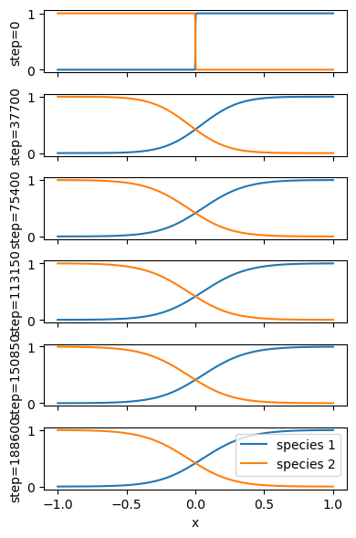

```python
# chose num_snapshots time points
num_snapshots = 6
# uniformed
indices = np.linspace(0, len(records_sym) - 1, num_snapshots, dtype=int)
# or chose what you like
#indices = [0, 1000, 3000, 11215]

record_interval = 50
steps_list = indices * record_interval

# draw

fig, axes = plt.subplots(num_snapshots, 1, figsize=(4, 6), sharex=True)

for i, idx in enumerate(indices):

    ax = axes[i]
    state = records_sym[idx]

    ax.plot(x, state[0], label='species 1')
    ax.plot(x, state[1], label='species 2')

    ax.set_ylabel(f"step={steps_list[i]}")

    #if i == 0:
    #   ax.set_title("Dynamics of Reaction-Diffusion System")

    if i == num_snapshots - 1:
        ax.set_xlabel("x")

    #ax.legend(loc="upper right")
plt.legend(loc="upper right")
plt.tight_layout()
plt.show()
```

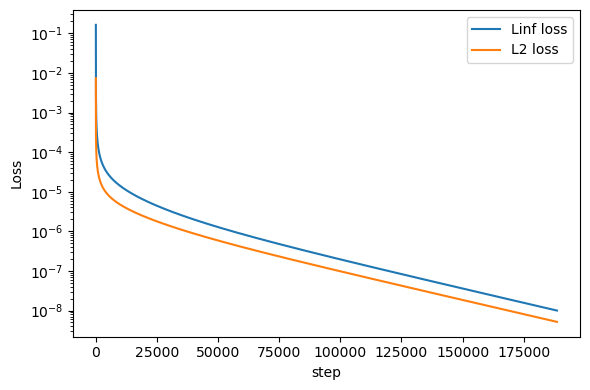

```python
# draw Loss

steps = np.arange(len(linf_loss_sym))

plt.figure(figsize=(6, 4))

plt.plot(steps, linf_loss_sym, label="Linf loss")
plt.plot(steps, l2_loss_sym, label="L2 loss")

plt.yscale("log")

plt.xlabel("step")
plt.ylabel("Loss")
plt.legend()

plt.tight_layout()
plt.show()
```

We now interested in the sum and contrast of two species. The later is supposed to be similar to a logistic distribution.

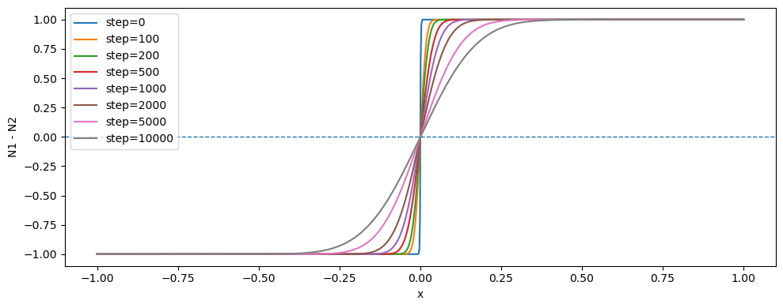

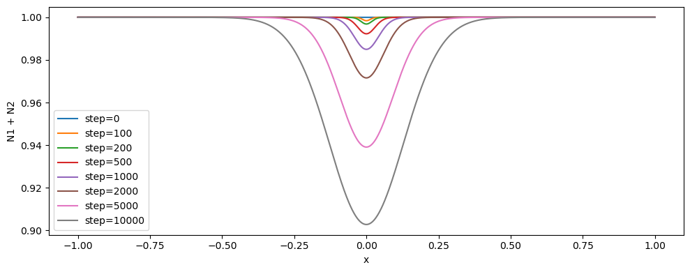

```python
# draw steps
target_steps = [0, 100, 200, 500, 1000, 2000, 5000, 10000]

record_interval = 50  # be same to the simulation

indices = [int(s // record_interval) for s in target_steps]

valid = [(s, idx) for s, idx in zip(target_steps, indices) if idx < len(records)]

# N1 - N2

plt.figure(figsize=(10, 4))

for step, idx in valid:
    state = records_sym[idx]
    N1, N2 = state[0], state[1]
    N_diff = N1 - N2

    plt.plot(x, N_diff, label=f"step={step}")

plt.axhline(0, linestyle="--", linewidth=1)

plt.xlabel("x")
plt.ylabel("N1 - N2")
#plt.title("Evolution of N1 - N2")
plt.legend()
plt.tight_layout()
plt.show()


# N1 + N2

plt.figure(figsize=(10, 4))

for step, idx in valid:
    state = records_sym[idx]
    N1, N2 = state[0], state[1]
    N_sum = N1 + N2

    plt.plot(x, N_sum, label=f"step={step}")

plt.xlabel("x")
plt.ylabel("N1 + N2")
#plt.title("Evolution of N1 + N2")
plt.legend()
plt.tight_layout()
plt.show()
```

Fit $N_1 - N_2$ to a logistic function $$ N_L(x) = \frac{K_1 - K_2}{1 + e^{-k(x - x_0)}} + K_2 $$

We here use $$ N_L(x) = \frac{A}{1 + e^{-k(x - x_0)}} + C $$

```python
final_state = records_sym[-1]
N1 = final_state[0]
N2 = final_state[1]

u = N1 - N2

# function: fit logistic

def fit_k_logistic(x, u, A=2.0, x0=0.0, C=-1.0, k0=10.0):

    def model(x, k):
        return A / (1 + np.exp(-k * (x - x0))) + C

    k_fit, _ = curve_fit(model, x, u, p0=[k0], maxfev=10000)

    return k_fit[0], model


k_fit, model = fit_k_logistic(x, u)

u_fit = model(x, k_fit)

# R^2

ss_res = np.sum((u - u_fit) ** 2)
ss_tot = np.sum((u - np.mean(u)) ** 2)

r2 = 1 - ss_res / ss_tot

print("===== Result =====")
print(f"k  = {k_fit:.4f}")
print(f"R² = {r2:.6f}")
```

```
===== Result =====
k  = 6.1647
R² = 0.999987
```

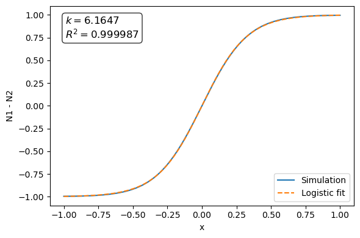

```python
# Draw N1-N2 and logistic fit

plt.figure(figsize=(6, 4))

plt.plot(x, u, label="Simulation")
plt.plot(x, u_fit, '--', label="Logistic fit")

textstr = '\n'.join((
    r'$k=%.4f$' % (k_fit,),
    r'$R^2=%.6f$' % (r2,)
))

plt.text(0.05, 0.95, textstr,
         transform=plt.gca().transAxes,
         fontsize=12,
         verticalalignment='top',
         bbox=dict(boxstyle='round', facecolor='white', alpha=0.8))

plt.xlabel("x")
plt.ylabel("N1 - N2")
#plt.title("Logistic Fit of Interface Profile")
plt.legend()

plt.tight_layout()
plt.show()
```

```python
def fit_k_logistic(x, u, A=2.0, x0=0.0, C=-1.0, k0=10.0):

    def model(x, k):
        return A / (1 + np.exp(-k * (x - x0))) + C

    k_fit, _ = curve_fit(model, x, u, p0=[k0], maxfev=10000)

    return k_fit[0]


# scan q from 0 to 2

q_values = np.linspace(0.0, 1.0, 20)
k_values = []

for q in q_values:

    D = [0.01, 0.01]
    r = [1.0, 1.0]

    # a = 1 + q
    A_mat = np.array([
        [1.0, 1.0 + q],
        [1.0 + q, 1.0]
    ])

    # simulate
    model = ReactionDiffusionIMEX(
        D=D,
        r=r,
        A=A_mat,
        xspan=(-1, 1),
        nx=200,
        dt=1e-4
    )

    x = model.x
    nx = len(x)

    N0 = np.zeros((2, nx))
    N0[0, x >= 0] = 1.0
    N0[1, x <= 0] = 1.0

    model.set_initial(N0)

    result = model.run(
        steps=200000,
        record_interval=None,
        steady_tol=1e-8,
        verbose=False
    )

    # final state
    final_state = model.N
    u = final_state[0] - final_state[1]

    # fit simulation result to logistic

    k_fit = fit_k_logistic(x, u)

    print(f"q={q:.3f}, k={k_fit:.4f}")

    k_values.append(k_fit)
```

```
q=0.000, k=2.4022
q=0.053, k=2.9468
q=0.105, k=3.4736
q=0.158, k=3.9634
q=0.211, k=4.4086
q=0.263, k=4.8090
q=0.316, k=5.1678
q=0.368, k=5.4897
q=0.421, k=5.7794
q=0.474, k=6.0419
q=0.526, k=6.2815
q=0.579, k=6.4989
q=0.632, k=6.6975
q=0.684, k=6.8798
q=0.737, k=7.0478
q=0.789, k=7.2033
q=0.842, k=7.3476
q=0.895, k=7.4820
q=0.947, k=7.6075
q=1.000, k=7.7249
```

We compare the approximated $k$ and simulated $k$ (as true value)

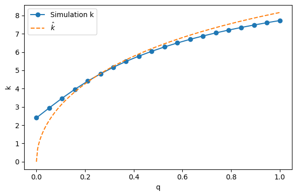

```python
plt.figure(figsize=(6, 4))

# simulated true value
plt.plot(q_values, k_values, 'o-', label="Simulation k")

# approximation
q_dense = np.linspace(0, 1, 200)
k_theory = np.sqrt(2*100*(q_dense)/(2+q_dense))

plt.plot(q_dense, k_theory, '--', label=r"$\hat{k}$")

plt.xlabel("q")
plt.ylabel("k")
#plt.title("k vs q")

plt.legend()
plt.tight_layout()
plt.show()
```

### Two asymmetric species

Now we do the same thing to asymmetric species. We choose parameters from the former $D-r$ heatmap, when $a = 1.25$, $b = 0.75$, species one take over.

```python
n = 2

D = [0.0125, 0.01]
r = [0.75, 1.0]

A = np.array([
    [1.0, 1.5],
    [1.5, 1.0]
])

model = ReactionDiffusionIMEX(
    D=D,
    r=r,
    A=A,
    xspan=(-1, 1),
    nx=1000,
    dt=1e-4
)

x = model.x
nx = len(x)

N0 = np.zeros((n, nx))

N0[0, x >= 0] = 1.0
N0[1, x <= 0] = 1.0

model.set_initial(N0)

result = model.run(
    steps=10000000,
    record_interval=50,
    steady_tol=1e-8,
    verbose=True
)

records_asymme = result["records"]
linf_loss_asym = result["linf_loss"]
l2_loss_asym = result["l2_loss"]

records_asym = np.array(records_asymme)
```

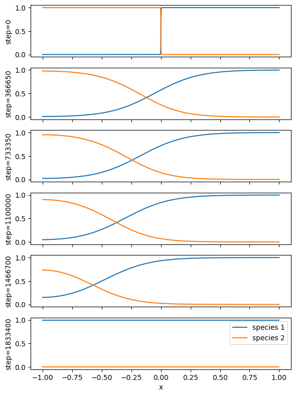

```python
# chose num_snapshots time points
num_snapshots = 6
# uniformed
indices = np.linspace(0, len(records_asym) - 1, num_snapshots, dtype=int)
# or chose what you like
#indices = [0, 1000, 3000, 11215]

record_interval = 50
steps_list = indices * record_interval

# draw

fig, axes = plt.subplots(num_snapshots, 1, figsize=(6, 8), sharex=True)

for i, idx in enumerate(indices):

    ax = axes[i]
    state = records_asym[idx]

    ax.plot(x, state[0], label='species 1')
    ax.plot(x, state[1], label='species 2')

    ax.set_ylabel(f"step={steps_list[i]}")

    #if i == 0:
    #   ax.set_title("Dynamics of Reaction-Diffusion System")

    if i == num_snapshots - 1:
        ax.set_xlabel("x")

    #ax.legend(loc="upper right")
plt.legend(loc="upper right")
plt.tight_layout()
plt.show()
```

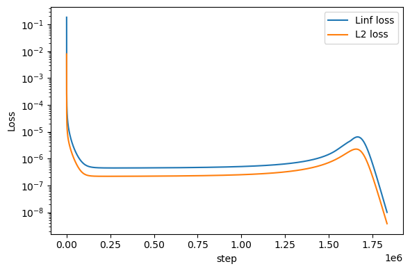

```python
# draw Loss

steps = np.arange(len(linf_loss_asym))

plt.figure(figsize=(6, 4))

plt.plot(steps, linf_loss_asym, label="Linf loss")
plt.plot(steps, l2_loss_asym, label="L2 loss")

plt.yscale("log")

plt.xlabel("step")
plt.ylabel("Loss")
plt.legend()

plt.tight_layout()
plt.show()
```

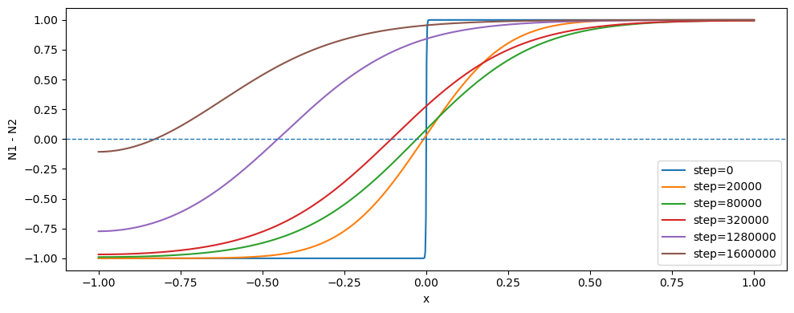

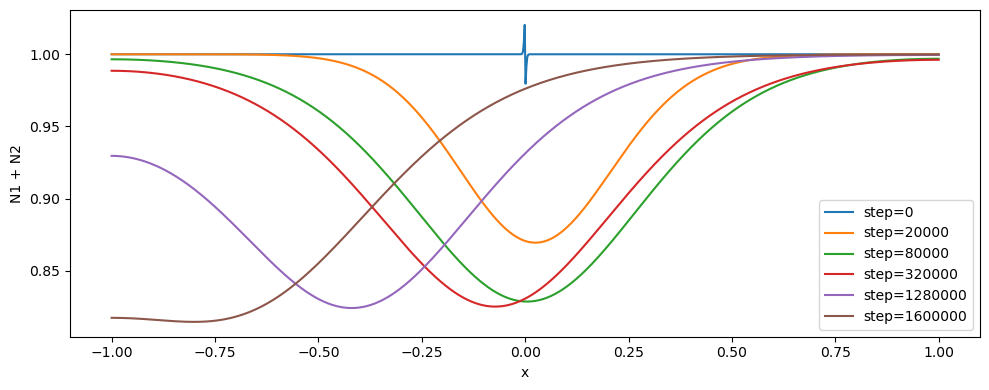

```python
# draw steps
target_steps = [0, 20000, 80000, 320000, 1280000, 1600000]

record_interval = 50  # be same to the simulation

indices = [int(s // record_interval) for s in target_steps]

valid = [(s, idx) for s, idx in zip(target_steps, indices) if idx < len(records_asym)]

# N1 - N2

plt.figure(figsize=(10, 4))

for step, idx in valid:
    state = records_asym[idx]
    N1, N2 = state[0], state[1]
    N_diff = N1 - N2

    plt.plot(x, N_diff, label=f"step={step}")

plt.axhline(0, linestyle="--", linewidth=1)

plt.xlabel("x")
plt.ylabel("N1 - N2")
#plt.title("Evolution of N1 - N2")
plt.legend()
plt.tight_layout()
plt.show()


# N1 + N2

plt.figure(figsize=(10, 4))

for step, idx in valid:
    state = records_asym[idx]
    N1, N2 = state[0], state[1]
    N_sum = N1 + N2

    plt.plot(x, N_sum, label=f"step={step}")

plt.xlabel("x")
plt.ylabel("N1 + N2")
#plt.title("Evolution of N1 + N2")
plt.legend()
plt.tight_layout()
plt.show()
```

### Multiple species: symmetric

We consider the condition where there are more species in each community. If the intra-community interactions are set to $1$, and inter-community interaction is higher, then the community is staill bi-stable and we could solve it as the two species condition.

```python
def make_block_matrix(n1, n2, inside=1.0, outside=1.5):

    N = n1 + n2
    A = np.full((N, N), outside)

    A[:n1, :n1] = inside
    A[n1:, n1:] = inside

    return A
```

```python
A = make_block_matrix(4, 3)

print(A)
```

```
[[1.  1.  1.  1.  1.5 1.5 1.5]
 [1.  1.  1.  1.  1.5 1.5 1.5]
 [1.  1.  1.  1.  1.5 1.5 1.5]
 [1.  1.  1.  1.  1.5 1.5 1.5]
 [1.5 1.5 1.5 1.5 1.  1.  1. ]
 [1.5 1.5 1.5 1.5 1.  1.  1. ]
 [1.5 1.5 1.5 1.5 1.  1.  1. ]]
```

```python
n = 6

D = np.full(n, 0.01)
r = np.full(n, 1)

A = make_block_matrix(3, 3)

model = ReactionDiffusionIMEX(
    D=D,
    r=r,
    A=A,
    xspan=(-1, 1),
    nx=1000,
    dt=1e-4
)

x = model.x
nx = len(x)

N0 = np.zeros((n, nx))

N0 = np.zeros((n, nx))

N0[0, x >= 0] = 0.5
N0[1, x >= 0] = 0.3
N0[2, x >= 0] = 0.2
N0[3, x <= 0] = 0.5
N0[4, x <= 0] = 0.3
N0[5, x <= 0] = 0.2

model.set_initial(N0)

result = model.run(
    steps=10000000,
    record_interval=50,
    steady_tol=1e-8,
    verbose=True
)

records_mult = result["records"]
linf_loss_mult = result["linf_loss"]
l2_loss_mult = result["l2_loss"]

records_mult = np.array(records_mult)
```

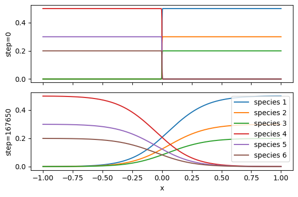

```python
# chose num_snapshots time points
num_snapshots = 2
# uniformed
indices = np.linspace(0, len(records_mult) - 1, num_snapshots, dtype=int)
# or chose what you like
#indices = [0, 1000, 3000, 11215]

record_interval = 50
steps_list = indices * record_interval

# draw

fig, axes = plt.subplots(num_snapshots, 1, figsize=(6, 4), sharex=True)

for i, idx in enumerate(indices):

    ax = axes[i]
    state = records_mult[idx]

    ax.plot(x, state[0], label='species 1')
    ax.plot(x, state[1], label='species 2')
    ax.plot(x, state[2], label='species 3')
    ax.plot(x, state[3], label='species 4')
    ax.plot(x, state[4], label='species 5')
    ax.plot(x, state[5], label='species 6')

    ax.set_ylabel(f"step={steps_list[i]}")

    #if i == 0:
    #   ax.set_title("Dynamics of Reaction-Diffusion System")

    if i == num_snapshots - 1:
        ax.set_xlabel("x")

    #ax.legend(loc="upper right")
plt.legend(loc="upper right")
plt.tight_layout()
plt.show()
```

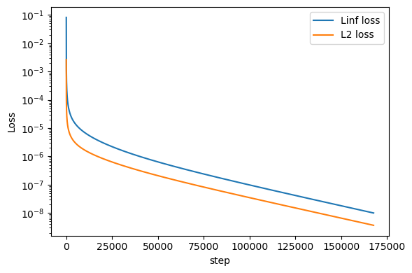

```python
# draw Loss

steps = np.arange(len(linf_loss_mult))

plt.figure(figsize=(6, 4))

plt.plot(steps, linf_loss_mult, label="Linf loss")
plt.plot(steps, l2_loss_mult, label="L2 loss")

plt.yscale("log")

plt.xlabel("step")
plt.ylabel("Loss")
plt.legend()

plt.tight_layout()
plt.show()
```

This time, the total population size in each community is important.

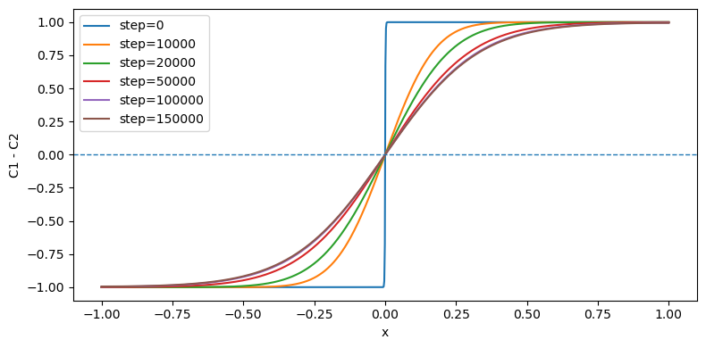

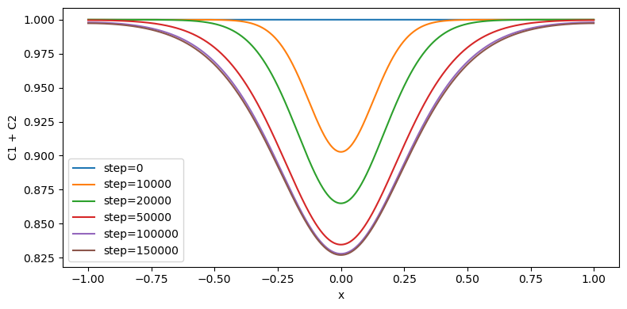

```python
target_steps = [0, 10000, 20000, 50000, 100000, 150000]

record_interval = 50

indices = [int(s // record_interval) for s in target_steps]

valid = [(s, idx) for s, idx in zip(target_steps, indices) if idx < len(records_mult)]

# =========================
# (state0+state1+state2) - (state3+state4+state5)
# =========================

plt.figure(figsize=(8, 4))

for step, idx in valid:
    state = records_mult[idx]

    G1 = state[0] + state[1] + state[2]
    G2 = state[3] + state[4] + state[5]

    N_diff = G1 - G2

    plt.plot(x, N_diff, label=f"step={step}")

plt.axhline(0, linestyle="--", linewidth=1)

plt.xlabel("x")
plt.ylabel("C1 - C2")
# plt.title("Evolution of Group Difference")
plt.legend()
plt.tight_layout()
plt.show()


# =========================
# (state0+state1+state2) + (state3+state4+state5)
# =========================

plt.figure(figsize=(8, 4))

for step, idx in valid:
    state = records_mult[idx]

    G1 = state[0] + state[1] + state[2]
    G2 = state[3] + state[4] + state[5]

    N_sum = G1 + G2

    plt.plot(x, N_sum, label=f"step={step}")

plt.xlabel("x")
plt.ylabel("C1 + C2")
# plt.title("Evolution of Group Sum")
plt.legend()
plt.tight_layout()
plt.show()
```

### Multiple: Different diffusion

```python
n = 16

D = np.tile(0.01*np.array([1, 1.05, 1.1, 1.15, 1.2, 1.25,1.3,1.35]), 2)
r = np.full(16, 1.0)

A = make_block_matrix(8, 8)

model = ReactionDiffusionIMEX(
    D=D,
    r=r,
    A=A,
    xspan=(-1, 1),
    nx=1000,
    dt=1e-4
)
x = model.x
nx = len(x)

N0 = np.zeros((n, nx))

N0[0, x >= 0] = 1/8
N0[1, x >= 0] = 1/8
N0[2, x >= 0] = 1/8
N0[3, x >= 0] = 1/8
N0[4, x >= 0] = 1/8
N0[5, x >= 0] = 1/8
N0[6, x >= 0] = 1/8
N0[7, x >= 0] = 1/8
N0[8, x <= 0] = 1/8
N0[9, x <= 0] = 1/8
N0[10, x <= 0] = 1/8
N0[11, x <= 0] = 1/8
N0[12, x <= 0] = 1/8
N0[13, x <= 0] = 1/8
N0[14, x <= 0] = 1/8
N0[15, x <= 0] = 1/8

model.set_initial(N0)

result = model.run(
    steps=10000000,
    record_interval=50,   # 控制存储密度
    steady_tol=1e-8,
    verbose=True
)

record_mult_d = result["records"]
linf_loss_mult_d = result["linf_loss"]
l2_loss_mult_d = result["l2_loss"]

record_mult_d = np.array(record_mult_d)
```

```python
record_mult_d_sparse = record_mult_d[::20]
```

```python
with open("record_mult_diffu.pkl", "wb") as f:
    pickle.dump(record_mult_d_sparse, f)

print("saved")
```

```
saved
```

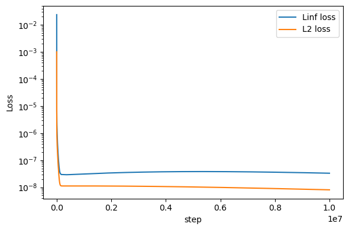

```python
# draw Loss

steps = np.arange(len(linf_loss_mult_d))

plt.figure(figsize=(6, 4))

plt.plot(steps, linf_loss_mult_d, label="Linf loss")
plt.plot(steps, l2_loss_mult_d, label="L2 loss")

plt.yscale("log")

plt.xlabel("step")
plt.ylabel("Loss")
plt.legend()

plt.tight_layout()
plt.show()
```

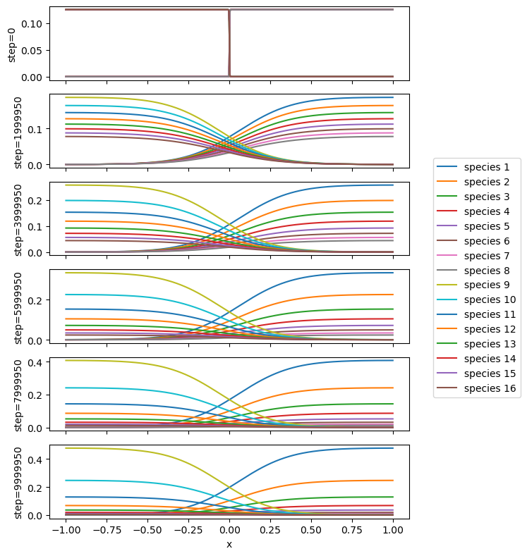

```python
num_snapshots = 6
indices = np.linspace(0, len(record_mult_d) - 1, num_snapshots, dtype=int)

record_interval = 50
steps_list = indices * record_interval

fig, axes = plt.subplots(num_snapshots, 1, figsize=(6, 8), sharex=True)

for i, idx in enumerate(indices):

    ax = axes[i]
    state = record_mult_d[idx]

    for j in range(n):
        ax.plot(x, state[j], label=f"species {j+1}")

    ax.set_ylabel(f"step={steps_list[i]}")

    # if i == 0:
    #     ax.set_title("Evolution of Reaction-Diffusion System")

    if i == num_snapshots - 1:
        ax.set_xlabel("x")

    #ax.legend(loc="upper right")

# legend together
handles, labels = axes[0].get_legend_handles_labels()

fig.legend(handles, labels,
           loc="center left",
           bbox_to_anchor=(1.02, 0.5))

plt.tight_layout(rect=[0, 0, 0.85, 1])
plt.tight_layout()
plt.show()
```

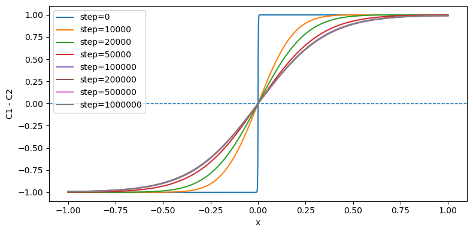

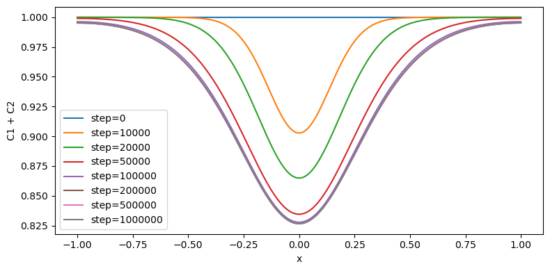

```python
n1 = 8
n2 = 8

target_steps = [0, 10000, 20000, 50000, 100000, 200000, 500000, 1000000]

record_interval = 50

indices = [int(s // record_interval) for s in target_steps]

valid = [(s, idx) for s, idx in zip(target_steps, indices) if idx < len(record_mult_d)]

# C1-C2

plt.figure(figsize=(8, 4))

for step, idx in valid:
    state = record_mult_d[idx]

    G1 = np.sum(state[:n1], axis=0)
    G2 = np.sum(state[n1:n1+n2], axis=0)

    N_diff = G1 - G2

    plt.plot(x, N_diff, label=f"step={step}")

plt.axhline(0, linestyle="--", linewidth=1)

plt.xlabel("x")
plt.ylabel("C1 - C2")
plt.legend()
plt.tight_layout()
plt.show()


# C1+C2

plt.figure(figsize=(8, 4))

for step, idx in valid:
    state = record_mult_d[idx]

    G1 = np.sum(state[:n1], axis=0)
    G2 = np.sum(state[n1:n1+n2], axis=0)

    N_sum = G1 + G2

    plt.plot(x, N_sum, label=f"step={step}")

plt.xlabel("x")
plt.ylabel("C1 + C2")
plt.legend()
plt.tight_layout()
plt.show()
```

# Pattern formation

With random initial state, periodic pattern may occurs in this species competition system, as other reaction-diffusion model.For example, in a 1D $2$ symmetric species system.

```python
n = 2

D = [0.01, 0.01]
r = [1.0, 1.0]

A = np.array([
    [1.0, 1.5],
    [1.5, 1.0]
])

model = ReactionDiffusionIMEX(
    D=D,
    r=r,
    A=A,
    xspan=(-10, 10),
    nx=1000,
    dt=1e-4
)

x = model.x
nx = len(x)

N0 = np.zeros((n, nx))

N0[0] = 0.5 + 0.5 * np.random.randn(1000)
N0[1] = 0.5 + 0.5 * np.random.randn(1000)

model.set_initial(N0)

result = model.run(
    steps=10000000,
    record_interval=50,
    steady_tol=1e-6,
    verbose=True
)

record_rand = result["records"]
linf_rand = result["linf_loss"]
l2_rand = result["l2_loss"]

record_rand = np.array(record_rand)
```

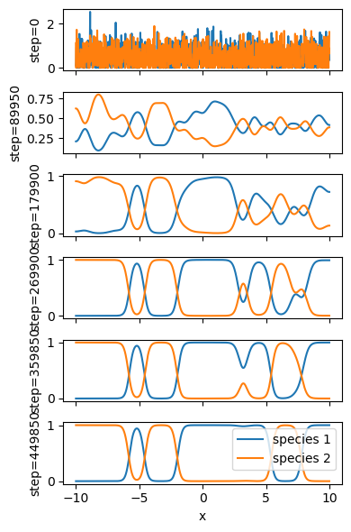

```python
# chose num_snapshots time points
num_snapshots = 6
# uniformed
indices = np.linspace(0, len(record_rand) - 1, num_snapshots, dtype=int)
# or chose what you like
#indices = [0, 1000, 3000, 11215]

record_interval = 50
steps_list = indices * record_interval

# draw

fig, axes = plt.subplots(num_snapshots, 1, figsize=(4, 6), sharex=True)

for i, idx in enumerate(indices):

    ax = axes[i]
    state = record_rand[idx]

    ax.plot(x, state[0], label='species 1')
    ax.plot(x, state[1], label='species 2')

    ax.set_ylabel(f"step={steps_list[i]}")

    #if i == 0:
    #   ax.set_title("Dynamics of Reaction-Diffusion System")

    if i == num_snapshots - 1:
        ax.set_xlabel("x")

    #ax.legend(loc="upper right")
plt.legend(loc="upper right")
plt.tight_layout()
plt.show()
```

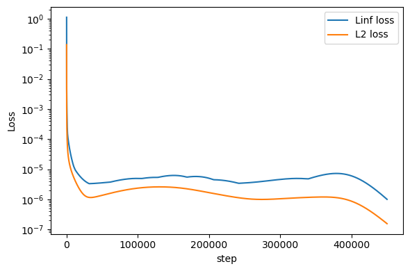

```python
# draw Loss

steps = np.arange(len(linf_rand))

plt.figure(figsize=(6, 4))

plt.plot(steps, linf_rand, label="Linf loss")
plt.plot(steps, l2_rand, label="L2 loss")

plt.yscale("log")

plt.xlabel("step")
plt.ylabel("Loss")
plt.legend()

plt.tight_layout()
plt.show()
```

Now we do the simulation on a plane. Initial state randomized.

```python
class ReactionDiffusion2D:
    """
    PDE
    ---
    \partial_t N_i = D_i \Delta N_i
             + r_i N_i (1 - \sum_j A_ij N_j)

    \Delta = \partial_xx + \partial_yy
    """

    def __init__(
        self,
        D,
        r,
        A,
        xspan=(0.0, 1.0),
        yspan=(0.0, 1.0),
        nx=128,
        ny=128,
        dt=1e-3,
    ):

        self.D = np.array(D, dtype=float)
        self.r = np.array(r, dtype=float)
        self.A = np.array(A, dtype=float)

        self.nspecies = len(D)

        # 网格
        self.xmin, self.xmax = xspan
        self.ymin, self.ymax = yspan

        self.nx = nx
        self.ny = ny

        self.dt = dt

        self.x = np.linspace(self.xmin, self.xmax, nx)
        self.y = np.linspace(self.ymin, self.ymax, ny)

        self.dx = self.x[1] - self.x[0]
        self.dy = self.y[1] - self.y[0]

        # 解数组
        # shape = (species, nx, ny)
        self.N = np.zeros((self.nspecies, nx, ny))

        # 误差
        self.last_linf_error = 0.0
        self.last_l2_error = 0.0

        # =====================================================
        # 构造二维 Laplacian
        # =====================================================

        Lx = self._build_1d_laplacian(nx, self.dx)
        Ly = self._build_1d_laplacian(ny, self.dy)

        Ix = sp.identity(nx, format='csr')
        Iy = sp.identity(ny, format='csr')

        # Kronecker:
        # Δ = Ix ⊗ Ly + Lx ⊗ Iy
        self.L = sp.kron(Ix, Ly) + sp.kron(Lx, Iy)

        # =====================================================
        # implicit solver
        # =====================================================

        self.solvers = []

        Ntot = nx * ny
        I = sp.identity(Ntot, format='csr')

        for Di in self.D:
            Aimp = I - self.dt * Di * self.L
            solver = spla.factorized(Aimp.tocsc())
            self.solvers.append(solver)

    # =========================================================
    # 1D Laplacian
    # =========================================================

    def _build_1d_laplacian(self, n, h):

        L = sp.lil_matrix((n, n))

        # 四阶内部点
        for i in range(2, n - 2):
            L[i, i - 2] = -1
            L[i, i - 1] = 16
            L[i, i] = -30
            L[i, i + 1] = 16
            L[i, i + 2] = -1

        # 二阶边界过渡
        L[1, 0] = 1
        L[1, 1] = -2
        L[1, 2] = 1

        L[n - 2, n - 3] = 1
        L[n - 2, n - 2] = -2
        L[n - 2, n - 1] = 1

        # Neumann BC
        L[0, 0] = -2
        L[0, 1] = 2

        L[n - 1, n - 2] = 2
        L[n - 1, n - 1] = -2

        # scaling
        L /= (12 * h**2)

        # 边界修正
        L[0, :] *= 12
        L[1, :] *= 12
        L[n - 2, :] *= 12
        L[n - 1, :] *= 12

        return L.tocsr()

    # =========================================================

    def set_initial(self, N0):

        self.N = np.array(N0, dtype=float).copy()

    # =========================================================

    def reaction_term(self, N):

        # N shape:
        # (species, nx, ny)

        interaction = np.einsum('ij,jxy->ixy', self.A, N)

        return N * self.r[:, None, None] * (1.0 - interaction)

    # =========================================================
    # 单步推进
    # =========================================================

    def step(self):

        Nold = self.N.copy()

        # reaction (explicit)
        R = self.reaction_term(self.N)

        rhs = self.N + self.dt * R

        Nnew = np.zeros_like(self.N)

        # 每个物种单独求解
        for i in range(self.nspecies):

            # flatten
            b = rhs[i].reshape(-1)

            # implicit solve
            sol = self.solvers[i](b)

            # reshape
            Nnew[i] = sol.reshape(self.nx, self.ny)

        # positivity
        Nnew = np.maximum(Nnew, 0.0)

        # =====================================================
        # 误差
        # =====================================================

        diff = Nnew - Nold

        linf_error = np.max(np.abs(diff))

        l2_error = np.sqrt(np.mean(diff**2))

        # update
        self.N = Nnew

        self.last_linf_error = linf_error
        self.last_l2_error = l2_error

        return linf_error, l2_error

    # =========================================================
    # 运行
    # =========================================================

    def run(
        self,
        steps,
        record_interval=None,
        steady_tol=None,
        verbose=False
    ):

        records = [] if record_interval is not None else None

        linf_history = []
        l2_history = []

        for k in range(steps):

            linf_err, l2_err = self.step()

            linf_history.append(linf_err)
            l2_history.append(l2_err)

            if verbose and k % 100 == 0:
                print(f"step={k}, Linf={linf_err:.3e}, L2={l2_err:.3e}")

            # steady state
            if steady_tol is not None and linf_err < steady_tol:

                if verbose:
                    print(
                        f"Steady state at step {k}, "
                        f"error={linf_err:.3e}"
                    )

                break

            # save snapshot
            if record_interval is not None:
                if k % record_interval == 0:
                    records.append(self.N.copy())

        return {
            "records": records,
            "linf_error": np.array(linf_history),
            "l2_error": np.array(l2_history),
        }
```

```python
D = [1e-5, 1e-5]

r = [1.0, 1.0]

A = [
    [1.0, 2],
    [2, 1.0]
]

model = ReactionDiffusion2D(
    D=D,
    r=r,
    A=A,
    nx=128,
    ny=128,
    dt=1e-2
)

N0 = np.zeros((2, 128, 128))

N0[0] = 0.5 + 0.5 * np.random.randn(128, 128)
N0[1] = 0.5 + 0.5 * np.random.randn(128, 128)
#N0[1] = 1 - N0[0]
model.set_initial(N0)
```

```python
result_2D = model.run(
    steps=100000,
    record_interval=100,
    steady_tol=1e-8,
    verbose=True
)
```

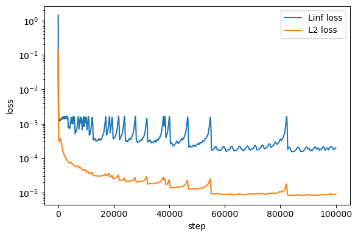

```python
linf_loss_2D = result_2D["linf_error"]
l2_loss_2D = result_2D["l2_error"]

steps = np.arange(len(linf_loss_2D))

plt.figure(figsize=(6, 4))

plt.plot(steps, linf_loss_2D, label="Linf loss")
plt.plot(steps, l2_loss_2D, label="L2 loss")

plt.yscale("log")

plt.xlabel("step")
plt.ylabel("loss")
plt.legend()

plt.tight_layout()
plt.show()
```

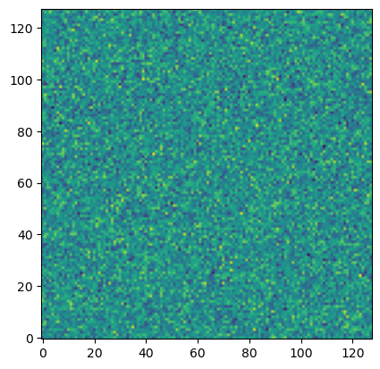

```python
plt.imshow(N0[1]-N0[0], origin='lower')
#plt.colorbar()
#plt.title("Species 0")
plt.show()
```

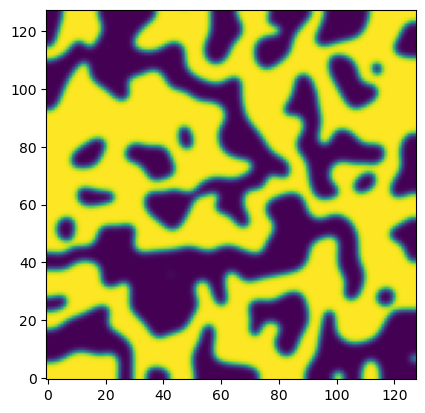

```python
records2 = result_2D["records"]
U = records2[50][0]
V = records2[50][1]

diff = U - V

plt.imshow(diff, origin='lower')
#plt.colorbar()
#plt.title("Species 0")
plt.show()
```

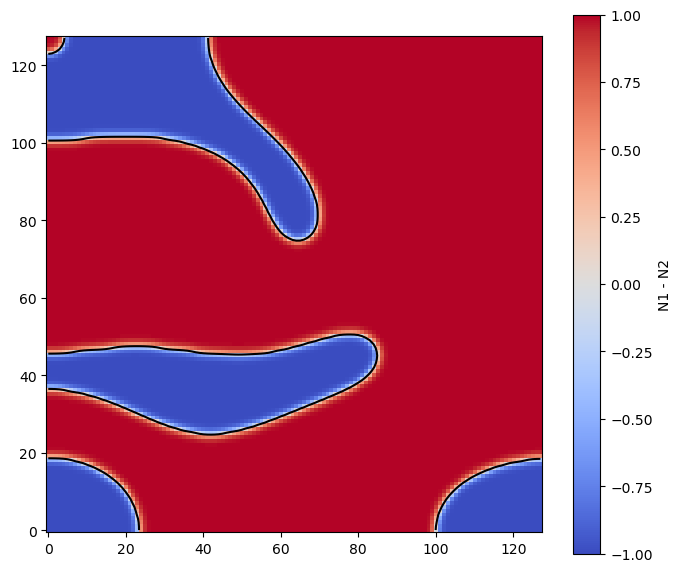

```python
U = model.N[0]
V = model.N[1]

diff = U - V

plt.figure(figsize=(8,7))

im = plt.imshow(
    diff,
    origin='lower',
    cmap='coolwarm'
)

plt.contour(
    diff,
    levels=[0],
    colors='black',
    linewidths=1.5
)

plt.colorbar(im, label='N1 - N2')

#plt.title("Dominance regions")

#plt.xlabel("x")
#plt.ylabel("y")

plt.show()
```